# Exploring the relationship between a set of variables and miles per gallon (MPG)

## Executive Summary

In this analysis I used the motor trend, a magazine about the automobile industry. Looking at a data set of a collection of cars, I am interested in exploring the relationship between a set of variables and miles per gallon (MPG) (outcome) and particularly interested in the following two questions:

Q. Is an automatic or manual transmission better for MPG.  
Q. Quantify the MPG difference between automatic and manual transmissions.

Doing linear regression on all variables and exploring relationship between miles per gallon with other variables. I choose those variables that have impact on our model and left others models. Then, I confirm my result by various measures, like regression plot and hypothesis testing. I came up with result that there is quite difference between automatic or manual transmission better for MPG.

## Data Processing

Firstly I grab libraries and dataset needed for that analysis.

```r
library(ggplot2)
data(mtcars)
data<-mtcars
```

## Exploratory Analysis

After that I do little bit of exploratory analysis for understanding, visually seeing and exploring relationships.

```r
summary(mtcars)
```

```
##       mpg             cyl             disp             hp
##  Min.   :10.40   Min.   :4.000   Min.   : 71.1   Min.   : 52.0
##  1st Qu.:15.43   1st Qu.:4.000   1st Qu.:120.8   1st Qu.: 96.5
##  Median :19.20   Median :6.000   Median :196.3   Median :123.0
##  Mean   :20.09   Mean   :6.188   Mean   :230.7   Mean   :146.7
##  3rd Qu.:22.80   3rd Qu.:8.000   3rd Qu.:326.0   3rd Qu.:180.0
##  Max.   :33.90   Max.   :8.000   Max.   :472.0   Max.   :335.0
##       drat             wt             qsec             vs
##  Min.   :2.760   Min.   :1.513   Min.   :14.50   Min.   :0.0000
##  1st Qu.:3.080   1st Qu.:2.581   1st Qu.:16.89   1st Qu.:0.0000
##  Median :3.695   Median :3.325   Median :17.71   Median :0.0000
##  Mean   :3.597   Mean   :3.217   Mean   :17.85   Mean   :0.4375
##  3rd Qu.:3.920   3rd Qu.:3.610   3rd Qu.:18.90   3rd Qu.:1.0000
##  Max.   :4.930   Max.   :5.424   Max.   :22.90   Max.   :1.0000
##        am              gear            carb
##  Min.   :0.0000   Min.   :3.000   Min.   :1.000
##  1st Qu.:0.0000   1st Qu.:3.000   1st Qu.:2.000
##  Median :0.0000   Median :4.000   Median :2.000
##  Mean   :0.4062   Mean   :3.688   Mean   :2.812
##  3rd Qu.:1.0000   3rd Qu.:4.000   3rd Qu.:4.000
##  Max.   :1.0000   Max.   :5.000   Max.   :8.000
```

```r
colnames(mtcars)
```

```
##  [1] "mpg"  "cyl"  "disp" "hp"   "drat" "wt"   "qsec" "vs"   "am"   "gear"
## [11] "carb"
```

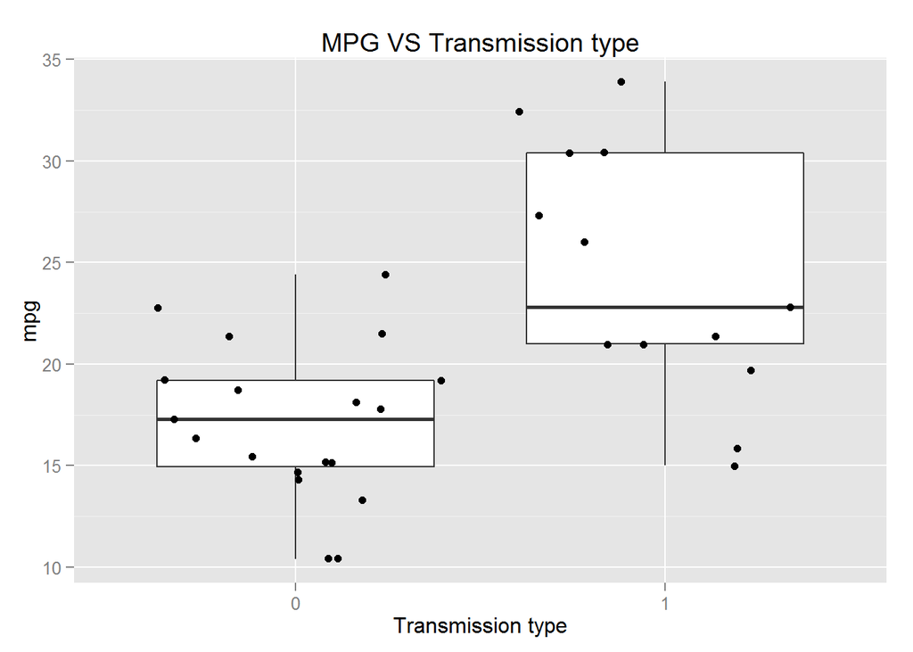

```r
p <- ggplot(mtcars, aes(factor(am), mpg))
p + geom_boxplot() + geom_jitter()+ggtitle("MPG VS Transmission type")+xlab("Transmission type")
```

## Model design and selection

```r
temp<-summary(lm(data=data,mpg~.-1))$coeff
temp[order(temp[,"Pr(>|t|)"]),]
```

```
##         Estimate Std. Error     t value   Pr(>|t|)
## qsec  1.19139689 0.45942323  2.59324480 0.01659185
## wt   -3.82613150 1.86238084 -2.05443023 0.05200271
## am    2.83222230 1.97512820  1.43394353 0.16564985
## hp   -0.02054767 0.02143989 -0.95838513 0.34828334
## drat  1.24158213 1.46276742  0.84878985 0.40513967
## gear  1.05426253 1.34668717  0.78285629 0.44205756
## disp  0.01354278 0.01762273  0.76848373 0.45037109
## cyl   0.35082641 0.76292423  0.45984438 0.65014009
## carb -0.26321386 0.81235653 -0.32401273 0.74898869
## vs    0.18972068 2.06824861  0.09173011 0.92774262
```

and then after selection top three that have impact and choosing wt, qsec, am and neglection others. Then fitting models and seeing quite improvment in p-value

```r
ImprovedData<-mtcars[,c("mpg","am","qsec","wt")]
temp<-summary(lm(data=ImprovedData,mpg~.-1))$coeff
temp[order(temp[,"Pr(>|t|)"]),]
```

```
##       Estimate Std. Error   t value     Pr(>|t|)
## qsec  1.599823  0.1021276 15.664944 1.091522e-15
## wt   -3.185455  0.4827586 -6.598442 3.128844e-07
## am    4.299519  1.0241147  4.198279 2.329423e-04
```

and seeing relation among them as,

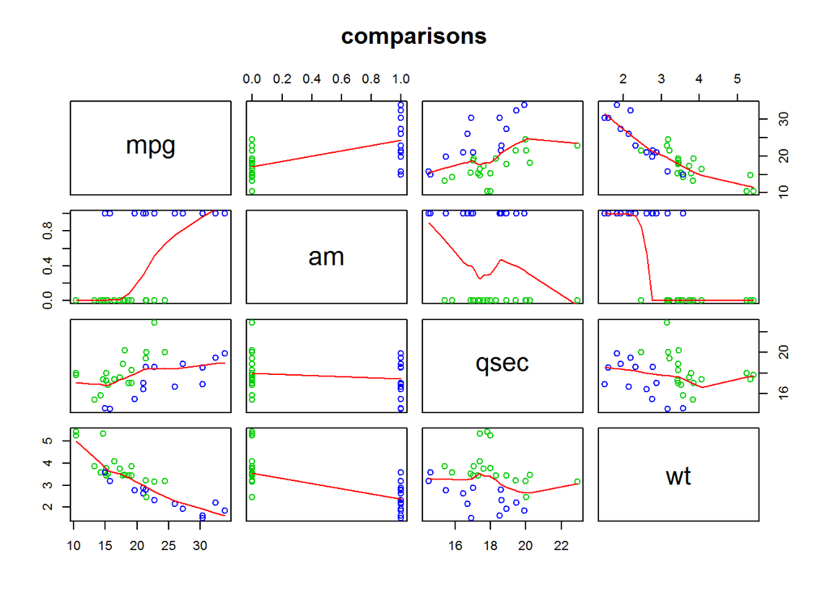

```r
pairs(ImprovedData, panel = panel.smooth, main = "comparisons",col=3+ImprovedData$am)
```

and then checking validation of my model,

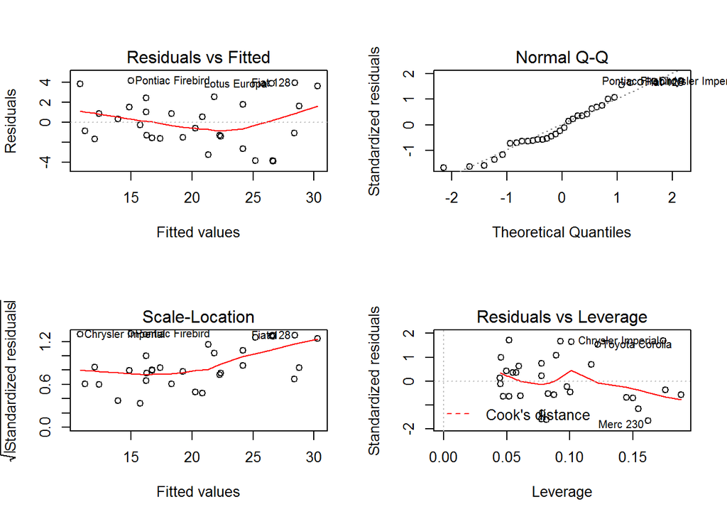

```r
par(mfrow = c(2, 2))
fit <- lm(mpg ~ . -1, data = ImprovedData); plot(fit)
```

and then quantifying the difference by the following graph

```r
par(mfrow = c(1, 1))
x<-mtcars$mpg
y<-mtcars$am+mtcars$wt+mtcars$qsec
plot(x,y,frame = FALSE,col=mtcars$am+3,cex=1,bg = "salmon")
abline(h = mean(y[mtcars$am==0]), lwd = 3,col="red")
abline(h = mean(y[mtcars$am==1]), lwd = 3,col="blue")
fit1<-lm(I(y[mtcars$am==0])~I(x[mtcars$am==0]))
summary(fit1)
```

```
##
## Call:
## lm(formula = I(y[mtcars$am == 0]) ~ I(x[mtcars$am == 0]))
##
## Residuals:
##     Min      1Q  Median      3Q     Max
## -2.1461 -1.1298 -0.1060  0.7301  3.2811
##
## Coefficients:
##                      Estimate Std. Error t value Pr(>|t|)
## (Intercept)          19.47419    1.70360  11.431 2.11e-09 ***
## I(x[mtcars$am == 0])  0.14450    0.09708   1.489    0.155
## ---
## Signif. codes:  0 '***' 0.001 '**' 0.01 '*' 0.05 '.' 0.1 ' ' 1
##
## Residual standard error: 1.579 on 17 degrees of freedom
## Multiple R-squared:  0.1153, Adjusted R-squared:  0.06327
## F-statistic: 2.216 on 1 and 17 DF,  p-value: 0.1549
```

```r
abline(fit1,col="red")
fit2<-lm(I(y[mtcars$am==1])~I(x[mtcars$am==1]))
summary(fit2)
```

```
##
## Call:
## lm(formula = I(y[mtcars$am == 1]) ~ I(x[mtcars$am == 1]))
##
## Residuals:
##     Min      1Q  Median      3Q     Max
## -2.2125 -0.8336 -0.2085  0.6504  2.0346
##
## Coefficients:
##                      Estimate Std. Error t value Pr(>|t|)
## (Intercept)          17.30167    1.41115   12.26 9.32e-08 ***
## I(x[mtcars$am == 1])  0.14223    0.05622    2.53    0.028 *
## ---
## Signif. codes:  0 '***' 0.001 '**' 0.01 '*' 0.05 '.' 0.1 ' ' 1
##
## Residual standard error: 1.201 on 11 degrees of freedom
## Multiple R-squared:  0.3678, Adjusted R-squared:  0.3104
## F-statistic: 6.401 on 1 and 11 DF,  p-value: 0.02797
```

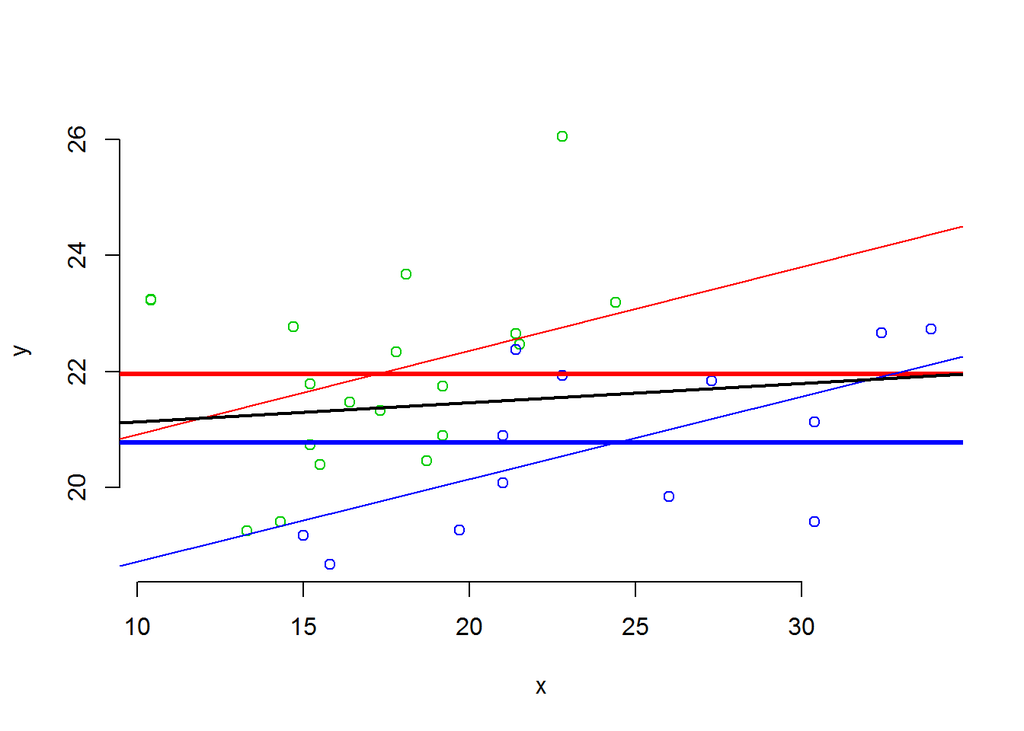

```r
abline(fit2,col="blue")
abline(lm(y~x),lwd=2)
```

## Conclusion

```r
coeff <-summary(lm(mpg~.-1, data = ImprovedData))$coeff
CInterval <- coeff["am", 1] + c(-1, 1) # qt(0.975, df = lm(mpg~.-1, data = ImprovedData)$df) # coeff["am",2]
CInterval
```

```
## [1] 3.299519 5.299519
```